# Assignment_5

Nick Climaco

2023-02-20

### Import packages

```r
library(tidyverse)
```

### Load the Data

The next chunk load the data from github with na.strings arguments that interprets the character vector as NA values. Then, we assign new value for row 2 column 1 in the dataframe df to “ALASKA” and the apply the same to row 5 column 1 to “AM West”.

```r
df <- read.csv("https://raw.githubusercontent.com/Nick-Climaco/Rdataset/main/Numbersenese_kaiserfung_data.csv",
    na.strings = c("", "NA"))
df[2, 1] <- "ALASKA"
df[5, 1] <- "AM West"
df
```

```
##         X      X.1 Los.Angeles Phoenix San.Diego San.Francisco Seattle
## 1  ALASKA on time          497     221       212           503    1841
## 2  ALASKA  delayed          61      12        20           102     305
## 3    <NA>     <NA>          NA      NA        NA            NA      NA
## 4 AM West  on time         694    4840       383           320     201
## 5 AM West  delayed         117     415        65           129      61
```

### Tidy and Clean

```r
df_filter <- df %>%
    filter(rowSums(is.na(.)) < ncol(.)) %>%
    rename(Airline = "X", Status = "X.1")
df_filter
```

```
##   Airline   Status Los.Angeles Phoenix San.Diego San.Francisco Seattle
## 1  ALASKA on time          497     221       212           503    1841
## 2  ALASKA  delayed          61      12        20           102     305
## 3 AM West  on time         694    4840       383           320     201
## 4 AM West  delayed         117     415        65           129      61
```

### Convert to long format using pivot_longer()

Using the pivot_longer() function, we can convert the data from wide format to long format. Thus tidying the data. The chunk below takes in the df_filter dataframe then pipes into the pivot_longer() function: where we selected the city columns that will be pivoted. Then, names_to = “City” will be a new column that will hold the old column names. values_to = “Count”, where “Count” will be a new column that will hold the values of the old columns.

```
-cols specifies the columns that will be pivoted
-names_to specifies the name of the column that will hold the name/s of
the old column name/s
-values_to specifies the name of the column that will hold the values
of the old column/s
```

```r
df_long <- df_filter %>%
    pivot_longer(cols = c("Los.Angeles", "Phoenix", "San.Diego", "San.Francisco", "Seattle"),
        names_to = "City", values_to = "Count")

head(df_long)
```

```
## # A tibble: 6 × 4
##   Airline Status     City          Count
##   <chr>   <chr>      <chr>         <int>
## 1 ALASKA  "on time " Los.Angeles     497
## 2 ALASKA  "on time " Phoenix         221
## 3 ALASKA  "on time " San.Diego       212
## 4 ALASKA  "on time " San.Francisco   503
## 5 ALASKA  "on time " Seattle        1841
## 6 ALASKA  "delayed"  Los.Angeles      61
```

### Analysis : for arrival delays for Alaska and AM West airlines

Here, creating a new datafram called df_summary where it takes the data from df_long, then using the group_by() to group by Airline and City then pipes into the summarise() function where it calculate the total number of delays, total number of flights, and the percentage of delays.

```r
df_summary <- df_long %>%
    group_by(Airline, City) %>%
    summarise(total_delays = sum(Count[Status == "delayed"]), total_flights = sum(Count), pct_delays = round(total_delays/total_flights,
        2))
df_summary
```

```
## # A tibble: 10 × 5
## # Groups:   Airline [2]
##    Airline City          total_delays total_flights pct_delays
##    <chr>   <chr>                <int>         <int>      <dbl>
##  1 ALASKA  Los.Angeles             61           558       0.11
##  2 ALASKA  Phoenix                 12           233       0.05
##  3 ALASKA  San.Diego               20           232       0.09
##  4 ALASKA  San.Francisco          102           605       0.17
##  5 ALASKA  Seattle                305          2146       0.14
##  6 AM West Los.Angeles            117           811       0.14
##  7 AM West Phoenix                415          5255       0.08
##  8 AM West San.Diego               65           448       0.15
##  9 AM West San.Francisco          129           449       0.29
## 10 AM West Seattle                 61           262       0.23
```

### Visualization

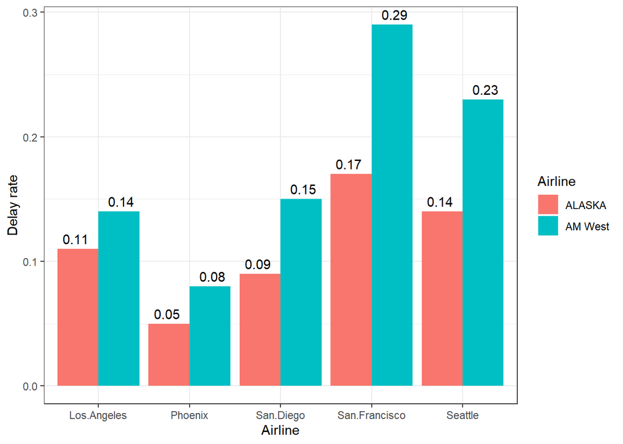

```r
ggplot(df_summary, aes(x = City, y = pct_delays, fill = Airline)) + geom_bar(stat = "identity",
    position = "dodge") + geom_text(aes(label = pct_delays), position = position_dodge(width = 1),
    vjust = -0.5) + labs(x = "Airline", y = "Delay rate", fill = "Airline") + theme_bw()
```

### Conclusion

From the given data and shown on the graph, it can be observed that AM West Airlines had a higher rate of arrival delays in these five cities relative to Alaska Airlines. The difference in delays rate is at least 3% which is indicative of a performance disparity between the two airlines in this closed experiment. Thus, the data suggests that traveling to these five cities, Alaska Airlines might be the better choice since it has a lower chance of a delayed arrival.